# Risk Factor Analysis

## Outcome Variable

**Outcome Variable:** wasted

## Predictor Variables

**Intervention Variable:** exclfeed36

**Adjustment Set:**

- arm
- sex
- W_mage
- meducyrs
- feducyrs
- hhwealth_quart
- hfoodsec
- W_mhtcm
- vagbrth
- W_gagebrth
- W_birthwt
- W_birthlen
- W_nrooms
- W_nchldlt5
- month
- brthmon
- W_parity
- impfloor
- impsan
- safeh20
- delta_W_mage
- delta_meducyrs
- delta_feducyrs
- delta_hhwealth_quart
- delta_hfoodsec
- delta_W_mhtcm
- delta_vagbrth
- delta_W_gagebrth
- delta_W_birthwt
- delta_W_birthlen
- delta_W_nrooms
- delta_W_nchldlt5
- delta_month
- delta_brthmon
- delta_W_parity
- delta_impfloor
- delta_impsan
- delta_safeh20

## Stratifying Variables

The analysis was stratified on these variable(s):

- agecat
- studyid
- country

## Data Summary

| agecat | studyid | country | exclfeed36 | wasted | n_cell | n |
| --- | --- | --- | --- | --- | --- | --- |
| Birth | ki0047075b-MAL-ED | BANGLADESH | 0 | 0 | 143 | 230 |
| Birth | ki0047075b-MAL-ED | BANGLADESH | 0 | 1 | 29 | 230 |
| Birth | ki0047075b-MAL-ED | BANGLADESH | 1 | 0 | 48 | 230 |
| Birth | ki0047075b-MAL-ED | BANGLADESH | 1 | 1 | 10 | 230 |
| Birth | ki0047075b-MAL-ED | BRAZIL | 0 | 0 | 159 | 177 |
| Birth | ki0047075b-MAL-ED | BRAZIL | 0 | 1 | 6 | 177 |
| Birth | ki0047075b-MAL-ED | BRAZIL | 1 | 0 | 12 | 177 |
| Birth | ki0047075b-MAL-ED | BRAZIL | 1 | 1 | 0 | 177 |
| Birth | ki0047075b-MAL-ED | INDIA | 0 | 0 | 157 | 195 |
| Birth | ki0047075b-MAL-ED | INDIA | 0 | 1 | 33 | 195 |
| Birth | ki0047075b-MAL-ED | INDIA | 1 | 0 | 5 | 195 |
| Birth | ki0047075b-MAL-ED | INDIA | 1 | 1 | 0 | 195 |
| Birth | ki0047075b-MAL-ED | NEPAL | 0 | 0 | 136 | 167 |
| Birth | ki0047075b-MAL-ED | NEPAL | 0 | 1 | 20 | 167 |
| Birth | ki0047075b-MAL-ED | NEPAL | 1 | 0 | 11 | 167 |
| Birth | ki0047075b-MAL-ED | NEPAL | 1 | 1 | 0 | 167 |
| Birth | ki0047075b-MAL-ED | PERU | 0 | 0 | 245 | 266 |
| Birth | ki0047075b-MAL-ED | PERU | 0 | 1 | 6 | 266 |
| Birth | ki0047075b-MAL-ED | PERU | 1 | 0 | 15 | 266 |
| Birth | ki0047075b-MAL-ED | PERU | 1 | 1 | 0 | 266 |
| Birth | ki0047075b-MAL-ED | SOUTH AFRICA | 0 | 0 | 220 | 234 |
| Birth | ki0047075b-MAL-ED | SOUTH AFRICA | 0 | 1 | 14 | 234 |
| Birth | ki0047075b-MAL-ED | SOUTH AFRICA | 1 | 0 | 0 | 234 |
| Birth | ki0047075b-MAL-ED | SOUTH AFRICA | 1 | 1 | 0 | 234 |
| Birth | ki0047075b-MAL-ED | TANZANIA, UNITED REPUBLIC OF | 0 | 0 | 113 | 116 |
| Birth | ki0047075b-MAL-ED | TANZANIA, UNITED REPUBLIC OF | 0 | 1 | 2 | 116 |
| Birth | ki0047075b-MAL-ED | TANZANIA, UNITED REPUBLIC OF | 1 | 0 | 1 | 116 |
| Birth | ki0047075b-MAL-ED | TANZANIA, UNITED REPUBLIC OF | 1 | 1 | 0 | 116 |
| Birth | ki1000108-CMC-V-BCS-2002 | INDIA | 0 | 0 | 0 | 3 |
| Birth | ki1000108-CMC-V-BCS-2002 | INDIA | 0 | 1 | 0 | 3 |

[output cut: 150 more lines]

The following strata were considered:

- agecat: 24 months, studyid: ki0047075b-MAL-ED, country: BANGLADESH
- agecat: 24 months, studyid: ki0047075b-MAL-ED, country: BRAZIL
- agecat: 24 months, studyid: ki0047075b-MAL-ED, country: INDIA
- agecat: 24 months, studyid: ki0047075b-MAL-ED, country: NEPAL
- agecat: 24 months, studyid: ki0047075b-MAL-ED, country: PERU
- agecat: 24 months, studyid: ki0047075b-MAL-ED, country: SOUTH AFRICA
- agecat: 24 months, studyid: ki0047075b-MAL-ED, country: TANZANIA, UNITED REPUBLIC OF
- agecat: 24 months, studyid: ki1000108-CMC-V-BCS-2002, country: INDIA
- agecat: 24 months, studyid: ki1000108-IRC, country: INDIA
- agecat: 24 months, studyid: ki1017093b-PROVIDE, country: BANGLADESH
- agecat: 24 months, studyid: ki1101329-Keneba, country: GAMBIA
- agecat: 24 months, studyid: ki1113344-GMS-Nepal, country: NEPAL
- agecat: 24 months, studyid: ki1148112-LCNI-5, country: MALAWI
- agecat: 24 months, studyid: kiGH5241-JiVitA-3, country: BANGLADESH
- agecat: 24 months, studyid: kiGH5241-JiVitA-4, country: BANGLADESH
- agecat: 6 months, studyid: ki0047075b-MAL-ED, country: BANGLADESH
- agecat: 6 months, studyid: ki0047075b-MAL-ED, country: BRAZIL
- agecat: 6 months, studyid: ki0047075b-MAL-ED, country: INDIA
- agecat: 6 months, studyid: ki0047075b-MAL-ED, country: NEPAL
- agecat: 6 months, studyid: ki0047075b-MAL-ED, country: PERU
- agecat: 6 months, studyid: ki0047075b-MAL-ED, country: SOUTH AFRICA
- agecat: 6 months, studyid: ki0047075b-MAL-ED, country: TANZANIA, UNITED REPUBLIC OF
- agecat: 6 months, studyid: ki1000108-CMC-V-BCS-2002, country: INDIA
- agecat: 6 months, studyid: ki1000108-IRC, country: INDIA
- agecat: 6 months, studyid: ki1000109-EE, country: PAKISTAN
- agecat: 6 months, studyid: ki1000304b-SAS-FoodSuppl, country: INDIA
- agecat: 6 months, studyid: ki1017093b-PROVIDE, country: BANGLADESH
- agecat: 6 months, studyid: ki1101329-Keneba, country: GAMBIA
- agecat: 6 months, studyid: ki1113344-GMS-Nepal, country: NEPAL
- agecat: 6 months, studyid: ki1148112-LCNI-5, country: MALAWI
- agecat: 6 months, studyid: kiGH5241-JiVitA-3, country: BANGLADESH
- agecat: 6 months, studyid: kiGH5241-JiVitA-4, country: BANGLADESH
- agecat: Birth, studyid: ki0047075b-MAL-ED, country: BANGLADESH
- agecat: Birth, studyid: ki0047075b-MAL-ED, country: BRAZIL
- agecat: Birth, studyid: ki0047075b-MAL-ED, country: INDIA
- agecat: Birth, studyid: ki0047075b-MAL-ED, country: NEPAL
- agecat: Birth, studyid: ki0047075b-MAL-ED, country: PERU
- agecat: Birth, studyid: ki0047075b-MAL-ED, country: SOUTH AFRICA
- agecat: Birth, studyid: ki0047075b-MAL-ED, country: TANZANIA, UNITED REPUBLIC OF
- agecat: Birth, studyid: ki1000108-CMC-V-BCS-2002, country: INDIA
- agecat: Birth, studyid: ki1000108-IRC, country: INDIA
- agecat: Birth, studyid: ki1000109-EE, country: PAKISTAN
- agecat: Birth, studyid: ki1101329-Keneba, country: GAMBIA
- agecat: Birth, studyid: kiGH5241-JiVitA-3, country: BANGLADESH
- agecat: Birth, studyid: kiGH5241-JiVitA-4, country: BANGLADESH

### Dropped Strata

Some strata were dropped due to rare outcomes:

- agecat: Birth, studyid: ki0047075b-MAL-ED, country: BRAZIL
- agecat: Birth, studyid: ki0047075b-MAL-ED, country: INDIA
- agecat: Birth, studyid: ki0047075b-MAL-ED, country: NEPAL
- agecat: Birth, studyid: ki0047075b-MAL-ED, country: PERU
- agecat: Birth, studyid: ki0047075b-MAL-ED, country: SOUTH AFRICA
- agecat: Birth, studyid: ki0047075b-MAL-ED, country: TANZANIA, UNITED REPUBLIC OF
- agecat: Birth, studyid: ki1000108-CMC-V-BCS-2002, country: INDIA
- agecat: Birth, studyid: ki1000108-IRC, country: INDIA
- agecat: Birth, studyid: ki1000109-EE, country: PAKISTAN
- agecat: 6 months, studyid: ki0047075b-MAL-ED, country: BANGLADESH
- agecat: 6 months, studyid: ki0047075b-MAL-ED, country: BRAZIL
- agecat: 6 months, studyid: ki0047075b-MAL-ED, country: INDIA
- agecat: 6 months, studyid: ki0047075b-MAL-ED, country: NEPAL
- agecat: 6 months, studyid: ki0047075b-MAL-ED, country: PERU
- agecat: 6 months, studyid: ki0047075b-MAL-ED, country: SOUTH AFRICA
- agecat: 6 months, studyid: ki0047075b-MAL-ED, country: TANZANIA, UNITED REPUBLIC OF
- agecat: 6 months, studyid: ki1000108-CMC-V-BCS-2002, country: INDIA
- agecat: 6 months, studyid: ki1000108-IRC, country: INDIA
- agecat: 6 months, studyid: ki1000304b-SAS-FoodSuppl, country: INDIA
- agecat: 6 months, studyid: ki1017093b-PROVIDE, country: BANGLADESH
- agecat: 6 months, studyid: ki1148112-LCNI-5, country: MALAWI
- agecat: 24 months, studyid: ki0047075b-MAL-ED, country: BRAZIL
- agecat: 24 months, studyid: ki0047075b-MAL-ED, country: INDIA
- agecat: 24 months, studyid: ki0047075b-MAL-ED, country: NEPAL
- agecat: 24 months, studyid: ki0047075b-MAL-ED, country: PERU
- agecat: 24 months, studyid: ki0047075b-MAL-ED, country: SOUTH AFRICA
- agecat: 24 months, studyid: ki0047075b-MAL-ED, country: TANZANIA, UNITED REPUBLIC OF
- agecat: 24 months, studyid: ki1000108-CMC-V-BCS-2002, country: INDIA
- agecat: 24 months, studyid: ki1000108-IRC, country: INDIA
- agecat: 24 months, studyid: ki1148112-LCNI-5, country: MALAWI

## Methods Detail

We’re interested in the causal parameters $E[Y_a]$ for all values of $a \in \mathcal{A}$. These parameters represent the mean outcome if, possibly contrary to fact, we intervened to set all units to have $A=a$. Under the randomization and positivity assumptions, these are identified by the statistical parameters $\psi_a=E_W[E_{Y|A,W}(Y|A=a,W)]$. In addition, we’re interested in the mean of $Y$, $E[Y]$ under no intervention (the observed mean). We will estimate these parameters by using SuperLearner to fit the relevant likelihood factors – $E_{Y|A,W}(Y|A=a,W)$ and $p(A=a|W)$, and then updating our likelihood fit using a joint TMLE.

For unadjusted analyses ($W=\{\}$), initial likelihoods were estimated using Lrnr_glm to estimate the simple $E(Y|A)$ and Lrnr_mean to estimate $p(A)$. For adjusted analyses, a small library containing Lrnr_glmnet, Lrnr_xgboost, and Lrnr_mean was used.

Having estimated these parameters, we will then use the delta method to estimate relative risks and attributable risks relative to a prespecified baseline level of $A$.

# Results Detail

## Results Plots

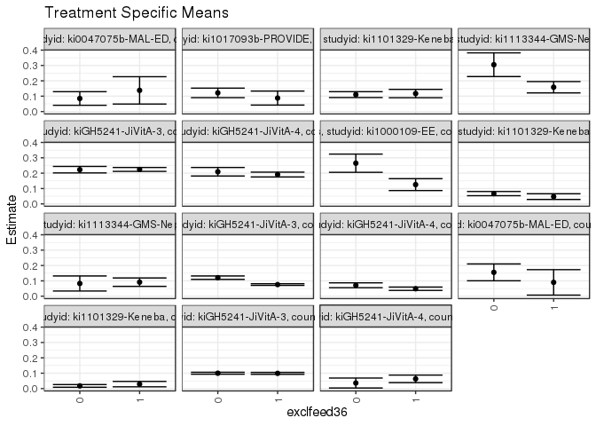

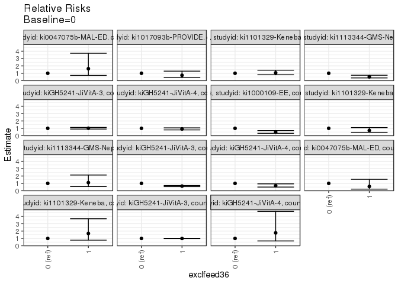

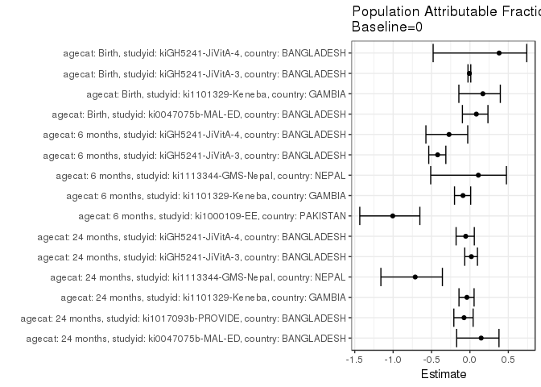

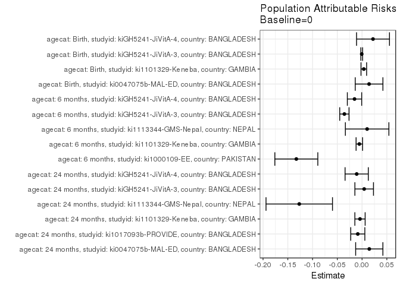

## Results Table

### Parameter: TSM

| agecat | studyid | country | intervention_level | baseline_level | estimate | ci_lower | ci_upper |
| --- | --- | --- | --- | --- | --- | --- | --- |
| Birth | ki0047075b-MAL-ED | BANGLADESH | 0 | NA | 0.1554150 | 0.1006456 | 0.2101844 |
| Birth | ki0047075b-MAL-ED | BANGLADESH | 1 | NA | 0.0901957 | 0.0074675 | 0.1729240 |
| Birth | ki1101329-Keneba | GAMBIA | 0 | NA | 0.0172904 | 0.0085524 | 0.0260285 |
| Birth | ki1101329-Keneba | GAMBIA | 1 | NA | 0.0289424 | 0.0114922 | 0.0463926 |
| Birth | kiGH5241-JiVitA-3 | BANGLADESH | 0 | NA | 0.0999019 | 0.0934995 | 0.1063043 |
| Birth | kiGH5241-JiVitA-3 | BANGLADESH | 1 | NA | 0.0990451 | 0.0928016 | 0.1052885 |
| Birth | kiGH5241-JiVitA-4 | BANGLADESH | 0 | NA | 0.0360360 | 0.0035958 | 0.0684763 |
| Birth | kiGH5241-JiVitA-4 | BANGLADESH | 1 | NA | 0.0631365 | 0.0385755 | 0.0876974 |
| 6 months | ki1000109-EE | PAKISTAN | 0 | NA | 0.2648456 | 0.2055364 | 0.3241547 |
| 6 months | ki1000109-EE | PAKISTAN | 1 | NA | 0.1254820 | 0.0869402 | 0.1640239 |
| 6 months | ki1101329-Keneba | GAMBIA | 0 | NA | 0.0670052 | 0.0533241 | 0.0806864 |
| 6 months | ki1101329-Keneba | GAMBIA | 1 | NA | 0.0473836 | 0.0288951 | 0.0658720 |
| 6 months | ki1113344-GMS-Nepal | NEPAL | 0 | NA | 0.0829390 | 0.0339015 | 0.1319765 |
| 6 months | ki1113344-GMS-Nepal | NEPAL | 1 | NA | 0.0914964 | 0.0641291 | 0.1188637 |
| 6 months | kiGH5241-JiVitA-3 | BANGLADESH | 0 | NA | 0.1207421 | 0.1095719 | 0.1319124 |
| 6 months | kiGH5241-JiVitA-3 | BANGLADESH | 1 | NA | 0.0758625 | 0.0704018 | 0.0813232 |
| 6 months | kiGH5241-JiVitA-4 | BANGLADESH | 0 | NA | 0.0713429 | 0.0555043 | 0.0871814 |
| 6 months | kiGH5241-JiVitA-4 | BANGLADESH | 1 | NA | 0.0487432 | 0.0379091 | 0.0595774 |
| 24 months | ki0047075b-MAL-ED | BANGLADESH | 0 | NA | 0.0849673 | 0.0406801 | 0.1292545 |
| 24 months | ki0047075b-MAL-ED | BANGLADESH | 1 | NA | 0.1379310 | 0.0489766 | 0.2268855 |
| 24 months | ki1017093b-PROVIDE | BANGLADESH | 0 | NA | 0.1214954 | 0.0905173 | 0.1524735 |
| 24 months | ki1017093b-PROVIDE | BANGLADESH | 1 | NA | 0.0878377 | 0.0421951 | 0.1334803 |
| 24 months | ki1101329-Keneba | GAMBIA | 0 | NA | 0.1102758 | 0.0911205 | 0.1294311 |
| 24 months | ki1101329-Keneba | GAMBIA | 1 | NA | 0.1172140 | 0.0900829 | 0.1443451 |
| 24 months | ki1113344-GMS-Nepal | NEPAL | 0 | NA | 0.3048890 | 0.2277962 | 0.3819819 |
| 24 months | ki1113344-GMS-Nepal | NEPAL | 1 | NA | 0.1583567 | 0.1215004 | 0.1952131 |
| 24 months | kiGH5241-JiVitA-3 | BANGLADESH | 0 | NA | 0.2228099 | 0.2016440 | 0.2439759 |
| 24 months | kiGH5241-JiVitA-3 | BANGLADESH | 1 | NA | 0.2243179 | 0.2115689 | 0.2370668 |
| 24 months | kiGH5241-JiVitA-4 | BANGLADESH | 0 | NA | 0.2091819 | 0.1813431 | 0.2370208 |
| 24 months | kiGH5241-JiVitA-4 | BANGLADESH | 1 | NA | 0.1909895 | 0.1752093 | 0.2067697 |

### Parameter: E(Y)

| agecat | studyid | country | intervention_level | baseline_level | estimate | ci_lower | ci_upper |
| --- | --- | --- | --- | --- | --- | --- | --- |
| Birth | ki0047075b-MAL-ED | BANGLADESH | NA | NA | 0.1695652 | 0.1209635 | 0.2181669 |
| Birth | ki1101329-Keneba | GAMBIA | NA | NA | 0.0207987 | 0.0127276 | 0.0288697 |
| Birth | kiGH5241-JiVitA-3 | BANGLADESH | NA | NA | 0.0992137 | 0.0929975 | 0.1054299 |
| Birth | kiGH5241-JiVitA-4 | BANGLADESH | NA | NA | 0.0581395 | 0.0372149 | 0.0790642 |
| 6 months | ki1000109-EE | PAKISTAN | NA | NA | 0.1320755 | 0.0975770 | 0.1665739 |
| 6 months | ki1101329-Keneba | GAMBIA | NA | NA | 0.0614525 | 0.0503239 | 0.0725811 |
| 6 months | ki1113344-GMS-Nepal | NEPAL | NA | NA | 0.0931559 | 0.0682937 | 0.1180181 |
| 6 months | kiGH5241-JiVitA-3 | BANGLADESH | NA | NA | 0.0849996 | 0.0797287 | 0.0902706 |
| 6 months | kiGH5241-JiVitA-4 | BANGLADESH | NA | NA | 0.0560882 | 0.0466363 | 0.0655401 |
| 24 months | ki0047075b-MAL-ED | BANGLADESH | NA | NA | 0.0995261 | 0.0590366 | 0.1400156 |
| 24 months | ki1017093b-PROVIDE | BANGLADESH | NA | NA | 0.1128472 | 0.0869854 | 0.1387090 |
| 24 months | ki1101329-Keneba | GAMBIA | NA | NA | 0.1060932 | 0.0899270 | 0.1222593 |
| 24 months | ki1113344-GMS-Nepal | NEPAL | NA | NA | 0.1780220 | 0.1428346 | 0.2132094 |
| 24 months | kiGH5241-JiVitA-3 | BANGLADESH | NA | NA | 0.2270683 | 0.2155455 | 0.2385912 |
| 24 months | kiGH5241-JiVitA-4 | BANGLADESH | NA | NA | 0.1983038 | 0.1835884 | 0.2130192 |

### Parameter: RR

| agecat | studyid | country | intervention_level | baseline_level | estimate | ci_lower | ci_upper |
| --- | --- | --- | --- | --- | --- | --- | --- |
| Birth | ki0047075b-MAL-ED | BANGLADESH | 0 | 0 | 1.0000000 | 1.0000000 | 1.0000000 |
| Birth | ki0047075b-MAL-ED | BANGLADESH | 1 | 0 | 0.5803541 | 0.2171250 | 1.5512303 |
| Birth | ki1101329-Keneba | GAMBIA | 0 | 0 | 1.0000000 | 1.0000000 | 1.0000000 |
| Birth | ki1101329-Keneba | GAMBIA | 1 | 0 | 1.6738962 | 0.7625848 | 3.6742514 |
| Birth | kiGH5241-JiVitA-3 | BANGLADESH | 0 | 0 | 1.0000000 | 1.0000000 | 1.0000000 |
| Birth | kiGH5241-JiVitA-3 | BANGLADESH | 1 | 0 | 0.9914228 | 0.9689778 | 1.0143878 |
| Birth | kiGH5241-JiVitA-4 | BANGLADESH | 0 | 0 | 1.0000000 | 1.0000000 | 1.0000000 |
| Birth | kiGH5241-JiVitA-4 | BANGLADESH | 1 | 0 | 1.7520367 | 0.6558927 | 4.6800833 |
| 6 months | ki1000109-EE | PAKISTAN | 0 | 0 | 1.0000000 | 1.0000000 | 1.0000000 |
| 6 months | ki1000109-EE | PAKISTAN | 1 | 0 | 0.4737933 | 0.3235744 | 0.6937510 |
| 6 months | ki1101329-Keneba | GAMBIA | 0 | 0 | 1.0000000 | 1.0000000 | 1.0000000 |
| 6 months | ki1101329-Keneba | GAMBIA | 1 | 0 | 0.7071621 | 0.4553219 | 1.0982963 |
| 6 months | ki1113344-GMS-Nepal | NEPAL | 0 | 0 | 1.0000000 | 1.0000000 | 1.0000000 |
| 6 months | ki1113344-GMS-Nepal | NEPAL | 1 | 0 | 1.1031765 | 0.5703602 | 2.1337368 |
| 6 months | kiGH5241-JiVitA-3 | BANGLADESH | 0 | 0 | 1.0000000 | 1.0000000 | 1.0000000 |
| 6 months | kiGH5241-JiVitA-3 | BANGLADESH | 1 | 0 | 0.6283019 | 0.5612042 | 0.7034217 |
| 6 months | kiGH5241-JiVitA-4 | BANGLADESH | 0 | 0 | 1.0000000 | 1.0000000 | 1.0000000 |
| 6 months | kiGH5241-JiVitA-4 | BANGLADESH | 1 | 0 | 0.6832252 | 0.4991828 | 0.9351217 |
| 24 months | ki0047075b-MAL-ED | BANGLADESH | 0 | 0 | 1.0000000 | 1.0000000 | 1.0000000 |
| 24 months | ki0047075b-MAL-ED | BANGLADESH | 1 | 0 | 1.6233422 | 0.7084127 | 3.7199216 |
| 24 months | ki1017093b-PROVIDE | BANGLADESH | 0 | 0 | 1.0000000 | 1.0000000 | 1.0000000 |
| 24 months | ki1017093b-PROVIDE | BANGLADESH | 1 | 0 | 0.7229713 | 0.4052726 | 1.2897184 |
| 24 months | ki1101329-Keneba | GAMBIA | 0 | 0 | 1.0000000 | 1.0000000 | 1.0000000 |
| 24 months | ki1101329-Keneba | GAMBIA | 1 | 0 | 1.0629167 | 0.7970512 | 1.4174646 |
| 24 months | ki1113344-GMS-Nepal | NEPAL | 0 | 0 | 1.0000000 | 1.0000000 | 1.0000000 |
| 24 months | ki1113344-GMS-Nepal | NEPAL | 1 | 0 | 0.5193914 | 0.3682534 | 0.7325592 |
| 24 months | kiGH5241-JiVitA-3 | BANGLADESH | 0 | 0 | 1.0000000 | 1.0000000 | 1.0000000 |
| 24 months | kiGH5241-JiVitA-3 | BANGLADESH | 1 | 0 | 1.0067677 | 0.9030332 | 1.1224186 |
| 24 months | kiGH5241-JiVitA-4 | BANGLADESH | 0 | 0 | 1.0000000 | 1.0000000 | 1.0000000 |
| 24 months | kiGH5241-JiVitA-4 | BANGLADESH | 1 | 0 | 0.9130305 | 0.7844418 | 1.0626980 |

### Parameter: PAR

| agecat | studyid | country | intervention_level | baseline_level | estimate | ci_lower | ci_upper |
| --- | --- | --- | --- | --- | --- | --- | --- |
| Birth | ki0047075b-MAL-ED | BANGLADESH | 0 | NA | 0.0141502 | -0.0138103 | 0.0421108 |
| Birth | ki1101329-Keneba | GAMBIA | 0 | NA | 0.0035082 | -0.0021623 | 0.0091788 |
| Birth | kiGH5241-JiVitA-3 | BANGLADESH | 0 | NA | -0.0006882 | -0.0024832 | 0.0011068 |
| Birth | kiGH5241-JiVitA-4 | BANGLADESH | 0 | NA | 0.0221035 | -0.0111471 | 0.0553541 |
| 6 months | ki1000109-EE | PAKISTAN | 0 | NA | -0.1327701 | -0.1761525 | -0.0893877 |
| 6 months | ki1101329-Keneba | GAMBIA | 0 | NA | -0.0055527 | -0.0120777 | 0.0009722 |
| 6 months | ki1113344-GMS-Nepal | NEPAL | 0 | NA | 0.0102169 | -0.0337296 | 0.0541634 |
| 6 months | kiGH5241-JiVitA-3 | BANGLADESH | 0 | NA | -0.0357425 | -0.0451327 | -0.0263523 |
| 6 months | kiGH5241-JiVitA-4 | BANGLADESH | 0 | NA | -0.0152546 | -0.0297484 | -0.0007609 |
| 24 months | ki0047075b-MAL-ED | BANGLADESH | 0 | NA | 0.0145587 | -0.0129426 | 0.0420601 |
| 24 months | ki1017093b-PROVIDE | BANGLADESH | 0 | NA | -0.0086482 | -0.0228727 | 0.0055764 |
| 24 months | ki1101329-Keneba | GAMBIA | 0 | NA | -0.0041826 | -0.0145746 | 0.0062094 |
| 24 months | ki1113344-GMS-Nepal | NEPAL | 0 | NA | -0.1268671 | -0.1939998 | -0.0597344 |
| 24 months | kiGH5241-JiVitA-3 | BANGLADESH | 0 | NA | 0.0042584 | -0.0145126 | 0.0230294 |
| 24 months | kiGH5241-JiVitA-4 | BANGLADESH | 0 | NA | -0.0108781 | -0.0343501 | 0.0125938 |

### Parameter: PAF

| agecat | studyid | country | intervention_level | baseline_level | estimate | ci_lower | ci_upper |
| --- | --- | --- | --- | --- | --- | --- | --- |
| Birth | ki0047075b-MAL-ED | BANGLADESH | 0 | NA | 0.0834500 | -0.0977662 | 0.2347515 |
| Birth | ki1101329-Keneba | GAMBIA | 0 | NA | 0.1686758 | -0.1440173 | 0.3959008 |
| Birth | kiGH5241-JiVitA-3 | BANGLADESH | 0 | NA | -0.0069367 | -0.0252147 | 0.0110155 |
| Birth | kiGH5241-JiVitA-4 | BANGLADESH | 0 | NA | 0.3801802 | -0.4789852 | 0.7402431 |
| 6 months | ki1000109-EE | PAKISTAN | 0 | NA | -1.0052592 | -1.4343156 | -0.6518255 |
| 6 months | ki1101329-Keneba | GAMBIA | 0 | NA | -0.0903581 | -0.2006858 | 0.0098320 |
| 6 months | ki1113344-GMS-Nepal | NEPAL | 0 | NA | 0.1096750 | -0.5106460 | 0.4752718 |
| 6 months | kiGH5241-JiVitA-3 | BANGLADESH | 0 | NA | -0.4205018 | -0.5361980 | -0.3135192 |
| 6 months | kiGH5241-JiVitA-4 | BANGLADESH | 0 | NA | -0.2719760 | -0.5731692 | -0.0284482 |
| 24 months | ki0047075b-MAL-ED | BANGLADESH | 0 | NA | 0.1462807 | -0.1727705 | 0.3785343 |
| 24 months | ki1017093b-PROVIDE | BANGLADESH | 0 | NA | -0.0766361 | -0.2093611 | 0.0415225 |
| 24 months | ki1101329-Keneba | GAMBIA | 0 | NA | -0.0394240 | -0.1423889 | 0.0542606 |
| 24 months | ki1113344-GMS-Nepal | NEPAL | 0 | NA | -0.7126484 | -1.1594000 | -0.3583238 |
| 24 months | kiGH5241-JiVitA-3 | BANGLADESH | 0 | NA | 0.0187539 | -0.0674120 | 0.0979641 |
| 24 months | kiGH5241-JiVitA-4 | BANGLADESH | 0 | NA | -0.0548559 | -0.1801445 | 0.0571316 |